# **Selected dplyr functions in R**

Wyclife Agumba Oluoch (wyclifeoluoch@gmail.com)

2021-11-22 22:15:56

# Introduction

We start this by converting Titanic table data to tibble. This is for easy manipulation with tidyverse packages. We also use `dim` function to check the number of rows and columns of the tibble.

```r
titanic_tibble <- tibble(data.frame(Titanic)) # Set Titanic data as tibble
dim(titanic_tibble)
```

```
## [1] 32  5
```

Checking the total number of passangers that boarded the Titanic.

```r
number_passengers <- titanic_tibble |> summarise(number_passengers = sum(Freq))
number_passengers
```

```
## # A tibble: 1 x 1
##   number_passengers
##               <dbl>
## 1              2201
```

Checking the total number of passengers who succumbed and those who survived the ordeal.

```r
number_survived <- titanic_tibble  |>
  group_by(Survived) |>
  summarise(Survival = sum(Freq))
number_survived
```

```
## # A tibble: 2 x 2
##   Survived Survival
##   <fct>       <dbl>
## 1 No           1490
## 2 Yes           711
```

Selecting a few columns from the tibble.

```r
data_sex_age_freq <- titanic_tibble |>
  select(Sex, Age, Freq)
data_sex_age_freq
```

```
## # A tibble: 32 x 3
##    Sex    Age    Freq
##    <fct>  <fct> <dbl>
##  1 Male   Child     0
##  2 Male   Child     0
##  3 Male   Child    35
##  4 Male   Child     0
##  5 Female Child     0
##  6 Female Child     0
##  7 Female Child    17
##  8 Female Child     0
##  9 Male   Adult   118
## 10 Male   Adult   154
## # ... with 22 more rows
```

# Mutate

Mutate creates a column using some conditional statements on other existing columns. For example, creating a new column which is 10 times the Freq column.

```r
titanic_tibble_mutate <- titanic_tibble |>
  mutate(Freq_10 = Freq * 10)
head(titanic_tibble_mutate)
```

```
## # A tibble: 6 x 6
##   Class Sex    Age   Survived  Freq Freq_10
##   <fct> <fct>  <fct> <fct>    <dbl>   <dbl>
## 1 1st   Male   Child No           0       0
## 2 2nd   Male   Child No           0       0
## 3 3rd   Male   Child No          35     350
## 4 Crew  Male   Child No           0       0
## 5 1st   Female Child No           0       0
## 6 2nd   Female Child No           0       0
```

Mutate normally adds the newly created column as the last in the tibble. However, that can be changed by specifying where you want it by .after or .before arguments. Here I use .after.

```r
titanic_tibble_mutate <- titanic_tibble |>
  mutate(Freq_10 = Freq * 10, .after = 1)
head(titanic_tibble_mutate)
```

```
## # A tibble: 6 x 6
##   Class Freq_10 Sex    Age   Survived  Freq
##   <fct>   <dbl> <fct>  <fct> <fct>    <dbl>
## 1 1st         0 Male   Child No           0
## 2 2nd         0 Male   Child No           0
## 3 3rd       350 Male   Child No          35
## 4 Crew        0 Male   Child No           0
## 5 1st         0 Female Child No           0
## 6 2nd         0 Female Child No           0
```

Here I use .before, hence making it even the first column.

```r
titanic_tibble_mutate <- titanic_tibble |>
  mutate(Freq_10 = Freq * 10, .before = 1)
head(titanic_tibble_mutate)
```

```
## # A tibble: 6 x 6
##   Freq_10 Class Sex    Age   Survived  Freq
##     <dbl> <fct> <fct>  <fct> <fct>    <dbl>
## 1       0 1st   Male   Child No           0
## 2       0 2nd   Male   Child No           0
## 3     350 3rd   Male   Child No          35
## 4       0 Crew  Male   Child No           0
## 5       0 1st   Female Child No           0
## 6       0 2nd   Female Child No           0
```

.after and .before do not only take column index like 1, 2, 3…but also take actual column names like is the case with Age column below.

```r
titanic_tibble_mutate <- titanic_tibble |>
  mutate(Freq_10 = Freq * 10, .after = Age)
head(titanic_tibble_mutate)
```

```
## # A tibble: 6 x 6
##   Class Sex    Age   Freq_10 Survived  Freq
##   <fct> <fct>  <fct>   <dbl> <fct>    <dbl>
## 1 1st   Male   Child       0 No           0
## 2 2nd   Male   Child       0 No           0
## 3 3rd   Male   Child     350 No          35
## 4 Crew  Male   Child       0 No           0
## 5 1st   Female Child       0 No           0
## 6 2nd   Female Child       0 No           0
```

Can have it located before Sex column.

```r
titanic_tibble_mutate <- titanic_tibble_mutate |>
  relocate(Age, .before = Sex)
head(titanic_tibble_mutate)
```

```
## # A tibble: 6 x 6
##   Class Age   Sex    Freq_10 Survived  Freq
##   <fct> <fct> <fct>    <dbl> <fct>    <dbl>
## 1 1st   Child Male         0 No           0
## 2 2nd   Child Male         0 No           0
## 3 3rd   Child Male       350 No          35
## 4 Crew  Child Male         0 No           0
## 5 1st   Child Female       0 No           0
## 6 2nd   Child Female       0 No           0
```

Or even after Sex.

```r
titanic_tibble_mutate <- titanic_tibble_mutate |>
  relocate(Age, .after = Sex)
head(titanic_tibble_mutate)
```

```
## # A tibble: 6 x 6
##   Class Sex    Age   Freq_10 Survived  Freq
##   <fct> <fct>  <fct>   <dbl> <fct>    <dbl>
## 1 1st   Male   Child       0 No           0
## 2 2nd   Male   Child       0 No           0
## 3 3rd   Male   Child     350 No          35
## 4 Crew  Male   Child       0 No           0
## 5 1st   Female Child       0 No           0
## 6 2nd   Female Child       0 No           0
```

# Mutate and case_when

A interesting and important functionality which can be appended to `mutate` is called `case_when`. This is almost working like `if_else`.

```r
titanic_tibble |> mutate(Remarks = case_when(Survived == 'Yes' ~ 'Awesome, you made it', Survived == 'No' ~ 'RIP', TRUE ~ 'Wishing you well')) |> group_by(Remarks) |> summarise(Number = sum(Freq))
```

```
## # A tibble: 2 x 2
##   Remarks              Number
##   <chr>                 <dbl>
## 1 Awesome, you made it    711
## 2 RIP                    1490
```

# Filter

Picks rows/records of a column meeting some defined conditions.

```r
titanic_female <- titanic_tibble |>
  filter(Sex == 'Female')
head(titanic_female)
```

```
## # A tibble: 6 x 5
##   Class Sex    Age   Survived  Freq
##   <fct> <fct>  <fct> <fct>    <dbl>
## 1 1st   Female Child No           0
## 2 2nd   Female Child No           0
## 3 3rd   Female Child No          17
## 4 Crew  Female Child No           0
## 5 1st   Female Adult No           4
## 6 2nd   Female Adult No          13
```

```r
titanic_tibble |>
  dplyr::filter(Age == 'Child' & Sex == 'Female' & Survived == 'Yes' & Class == '1st')
```

```
## # A tibble: 1 x 5
##   Class Sex    Age   Survived  Freq
##   <fct> <fct>  <fct> <fct>    <dbl>
## 1 1st   Female Child Yes          1
```

```r
titanic_tibble |>
  dplyr::filter(Age == 'Child' & Sex == 'Male' & Survived == 'Yes' & Class == '1st')
```

```
## # A tibble: 1 x 5
##   Class Sex   Age   Survived  Freq
##   <fct> <fct> <fct> <fct>    <dbl>
## 1 1st   Male  Child Yes          5
```

# Arrange

```r
titanic_df <- base::data.frame(Titanic)
nrow(titanic_df)
```

```
## [1] 32
```

```r
titanic_tibble <- tibble::tibble(titanic_df)
```

```r
titanic_tibble <- titanic_tibble |>
  dplyr::arrange(Freq)
```

```r
utils::head(titanic_tibble)
```

```
## # A tibble: 6 x 5
##   Class Sex    Age   Survived  Freq
##   <fct> <fct>  <fct> <fct>    <dbl>
## 1 1st   Male   Child No           0
## 2 2nd   Male   Child No           0
## 3 Crew  Male   Child No           0
## 4 1st   Female Child No           0
## 5 2nd   Female Child No           0
## 6 Crew  Female Child No           0
```

```r
utils::tail(titanic_tibble)
```

```
## # A tibble: 6 x 5
##   Class Sex    Age   Survived  Freq
##   <fct> <fct>  <fct> <fct>    <dbl>
## 1 1st   Male   Adult No         118
## 2 1st   Female Adult Yes        140
## 3 2nd   Male   Adult No         154
## 4 Crew  Male   Adult Yes        192
## 5 3rd   Male   Adult No         387
## 6 Crew  Male   Adult No         670
```

```r
titanic_tibble <- titanic_tibble |>
  arrange(desc(Freq))
```

```r
head(titanic_tibble)
```

```
## # A tibble: 6 x 5
##   Class Sex    Age   Survived  Freq
##   <fct> <fct>  <fct> <fct>    <dbl>
## 1 Crew  Male   Adult No         670
## 2 3rd   Male   Adult No         387
## 3 Crew  Male   Adult Yes        192
## 4 2nd   Male   Adult No         154
## 5 1st   Female Adult Yes        140
## 6 1st   Male   Adult No         118
```

```r
titanic_tibble |>
  arrange(desc(Freq), Survived)
```

```
## # A tibble: 32 x 5
##    Class Sex    Age   Survived  Freq
##    <fct> <fct>  <fct> <fct>    <dbl>
##  1 Crew  Male   Adult No         670
##  2 3rd   Male   Adult No         387
##  3 Crew  Male   Adult Yes        192
##  4 2nd   Male   Adult No         154
##  5 1st   Female Adult Yes        140
##  6 1st   Male   Adult No         118
##  7 3rd   Female Adult No          89
##  8 2nd   Female Adult Yes         80
##  9 3rd   Female Adult Yes         76
## 10 3rd   Male   Adult Yes         75
## # ... with 22 more rows
```

# Correlation

```r
utils::data(flights)
```

```r
flights |>
  dplyr::summarise(delay_cor = stats::cor(dep_delay, arr_delay))
```

```
## # A tibble: 1 x 1
##   delay_cor
##       <dbl>
## 1        NA
```

```r
flights |>
  dplyr::summarise(delay_cor = stats::cor(dep_delay, arr_delay, use = 'complete.obs'))
```

```
## # A tibble: 1 x 1
##   delay_cor
##       <dbl>
## 1     0.915
```

```r
flights |>
  dplyr::select(dep_delay, arr_delay) |>
  stats::na.omit() |>
  dplyr::summarise(delay_cor = stats::cor(dep_delay, arr_delay))
```

```
## # A tibble: 1 x 1
##   delay_cor
##       <dbl>
## 1     0.915
```

# Iris

```r
utils::data("iris")
```

```r
score_model <- stats::lm(Sepal.Length ~ Petal.Width, data = iris)
score_model|>
  base::summary()
```

```
##
## Call:
## stats::lm(formula = Sepal.Length ~ Petal.Width, data = iris)
##
## Residuals:
##      Min       1Q   Median       3Q      Max
## -1.38822 -0.29358 -0.04393  0.26429  1.34521
##
## Coefficients:
##             Estimate Std. Error t value Pr(>|t|)
## (Intercept)  4.77763    0.07293   65.51   <2e-16 ***
## Petal.Width  0.88858    0.05137   17.30   <2e-16 ***
## ---
## Signif. codes:  0 '***' 0.001 '**' 0.01 '*' 0.05 '.' 0.1 ' ' 1
##
## Residual standard error: 0.478 on 148 degrees of freedom
## Multiple R-squared:  0.669,  Adjusted R-squared:  0.6668
## F-statistic: 299.2 on 1 and 148 DF,  p-value: < 2.2e-16
```

```r
broom::tidy(score_model)
```

```
## # A tibble: 2 x 5
##   term        estimate std.error statistic   p.value
##   <chr>          <dbl>     <dbl>     <dbl>     <dbl>
## 1 (Intercept)    4.78     0.0729      65.5 3.34e-111
## 2 Petal.Width    0.889    0.0514      17.3 2.33e- 37
```

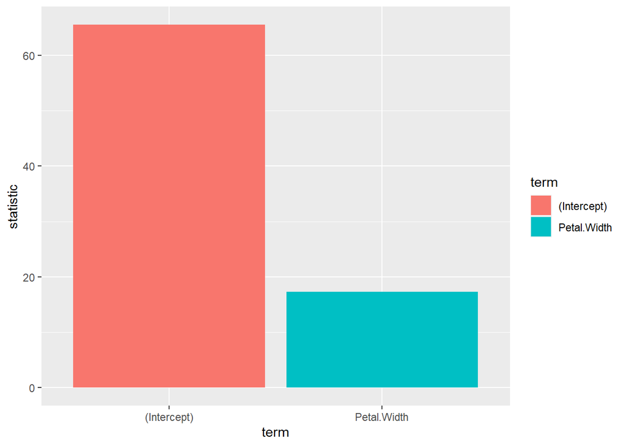

```r
broom::tidy(score_model) |>
  ggplot2::ggplot() +
  ggplot2::geom_col(ggplot2::aes(x = term, y = statistic, fill = term))
```

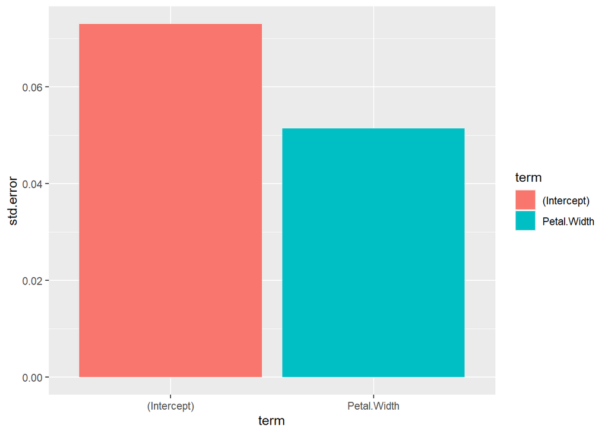

```r
iris |>
  dplyr::select(Sepal.Length, Petal.Width) |>
  stats::lm() |>
  broom::tidy() |>
  ggplot2::ggplot() +
  ggplot2::geom_col(ggplot2::aes(x = term, y = std.error, fill = term))
```

```r
broom::glance(score_model)
```

```
## # A tibble: 1 x 12
##   r.squared adj.r.squared sigma statistic  p.value    df logLik   AIC   BIC
##       <dbl>         <dbl> <dbl>     <dbl>    <dbl> <dbl>  <dbl> <dbl> <dbl>
## 1     0.669         0.667 0.478      299. 2.33e-37     1  -101.  208.  217.
## # ... with 3 more variables: deviance <dbl>, df.residual <int>, nobs <int>
```

```r
moderndive::get_regression_summaries(score_model)
```

```
## # A tibble: 1 x 9
##   r_squared adj_r_squared   mse  rmse sigma statistic p_value    df  nobs
##       <dbl>         <dbl> <dbl> <dbl> <dbl>     <dbl>   <dbl> <dbl> <dbl>
## 1     0.669         0.667 0.225 0.475 0.478      299.       0     1   150
```

```r
broom::augment(score_model)
```

```
## # A tibble: 150 x 8
##    Sepal.Length Petal.Width .fitted  .resid   .hat .sigma   .cooksd .std.resid
##           <dbl>       <dbl>   <dbl>   <dbl>  <dbl>  <dbl>     <dbl>      <dbl>
##  1          5.1         0.2    4.96  0.145  0.0182  0.479 0.000865      0.305
##  2          4.9         0.2    4.96 -0.0553 0.0182  0.480 0.000127     -0.117
##  3          4.7         0.2    4.96 -0.255  0.0182  0.479 0.00269      -0.539
##  4          4.6         0.2    4.96 -0.355  0.0182  0.479 0.00522      -0.750
##  5          5           0.2    4.96  0.0447 0.0182  0.480 0.0000824     0.0943
##  6          5.4         0.4    5.13  0.267  0.0140  0.479 0.00225       0.562
##  7          4.6         0.3    5.04 -0.444  0.0160  0.478 0.00714      -0.937
##  8          5           0.2    4.96  0.0447 0.0182  0.480 0.0000824     0.0943
##  9          4.4         0.2    4.96 -0.555  0.0182  0.477 0.0127       -1.17
## 10          4.9         0.1    4.87  0.0335 0.0206  0.480 0.0000529     0.0708
## # ... with 140 more rows
```

```r
moderndive::get_regression_points(score_model)
```

```
## # A tibble: 150 x 5
##       ID Sepal.Length Petal.Width Sepal.Length_hat residual
##    <int>        <dbl>       <dbl>            <dbl>    <dbl>
##  1     1          5.1         0.2             4.96    0.145
##  2     2          4.9         0.2             4.96   -0.055
##  3     3          4.7         0.2             4.96   -0.255
##  4     4          4.6         0.2             4.96   -0.355
##  5     5          5           0.2             4.96    0.045
##  6     6          5.4         0.4             5.13    0.267
##  7     7          4.6         0.3             5.04   -0.444
##  8     8          5           0.2             4.96    0.045
##  9     9          4.4         0.2             4.96   -0.555
## 10    10          4.9         0.1             4.87    0.034
## # ... with 140 more rows
```

```r
anova_iris <- stats::aov(Sepal.Length ~ Petal.Width, data = iris)
broom::tidy(anova_iris)
```

```
## # A tibble: 2 x 6
##   term           df sumsq meansq statistic   p.value
##   <chr>       <dbl> <dbl>  <dbl>     <dbl>     <dbl>
## 1 Petal.Width     1  68.4 68.4        299.  2.33e-37
## 2 Residuals     148  33.8  0.228       NA  NA
```

```r
utils::data(iris)
utils::head(iris)
```

```
##   Sepal.Length Sepal.Width Petal.Length Petal.Width Species
## 1          5.1         3.5          1.4         0.2  setosa
## 2          4.9         3.0          1.4         0.2  setosa
## 3          4.7         3.2          1.3         0.2  setosa
## 4          4.6         3.1          1.5         0.2  setosa
## 5          5.0         3.6          1.4         0.2  setosa
## 6          5.4         3.9          1.7         0.4  setosa
```

```r
stats::aggregate(x = base::c(iris$Sepal.Length),
          by = base::list(iris$Species),
          FUN = sum)
```

```
##      Group.1     x
## 1     setosa 250.3
## 2 versicolor 296.8
## 3  virginica 329.4
```

```r
iris |>
  dplyr::group_by(Species) |>
  dplyr::summarise(x = base::sum(Sepal.Length))
```

```
## # A tibble: 3 x 2
##   Species        x
##   <fct>      <dbl>
## 1 setosa      250.
## 2 versicolor  297.
## 3 virginica   329.
```

```r
iris |>
  dplyr::group_by(Species) |>
  dplyr::summarise(`sum(Sepal.Length)` = base::sprintf('%0.1f', base::sum(Sepal.Length)))
```

```
## # A tibble: 3 x 2
##   Species    `sum(Sepal.Length)`
##   <fct>      <chr>
## 1 setosa     250.3
## 2 versicolor 296.8
## 3 virginica  329.4
```

```r
iris |>
  dplyr::group_by(Species) |>
  dplyr::summarise(`sum(Sepal.Length)` = base::sprintf('%0.4f', base::sum(Sepal.Length)))
```

```
## # A tibble: 3 x 2
##   Species    `sum(Sepal.Length)`
##   <fct>      <chr>
## 1 setosa     250.3000
## 2 versicolor 296.8000
## 3 virginica  329.4000
```

```r
library(reticulate)
```

```python
import numpy as np
my_python_array = np.array([2,4,6,8])
for item in my_python_array:
  print(item)
```

```
## 2
## 4
## 6
## 8
```

# References

Allaire, JJ, Yihui Xie, Jonathan McPherson, Javier Luraschi, Kevin Ushey, Aron Atkins, Hadley Wickham, Joe Cheng, Winston Chang, and Richard Iannone. 2021. *Rmarkdown: Dynamic Documents for r*. https://CRAN.R-project.org/package=rmarkdown.

Henry, Lionel, and Hadley Wickham. 2020. *Purrr: Functional Programming Tools*. https://CRAN.R-project.org/package=purrr.

Kim, Albert Y., and Chester Ismay. 2021. *Moderndive: Tidyverse-Friendly Introductory Linear Regression*. https://github.com/moderndive/moderndive/issues.

Müller, Kirill, and Hadley Wickham. 2021. *Tibble: Simple Data Frames*. https://CRAN.R-project.org/package=tibble.

R Core Team. 2021. *R: A Language and Environment for Statistical Computing*. Vienna, Austria: R Foundation for Statistical Computing. https://www.R-project.org/.

Robinson, David, Alex Hayes, and Simon Couch. 2021. *Broom: Convert Statistical Objects into Tidy Tibbles*. https://CRAN.R-project.org/package=broom.

Wickham, Hadley. 2016. *Ggplot2: Elegant Graphics for Data Analysis*. Springer-Verlag New York. https://ggplot2.tidyverse.org.

———. 2019. *Stringr: Simple, Consistent Wrappers for Common String Operations*. https://CRAN.R-project.org/package=stringr.

———. 2021a. *Forcats: Tools for Working with Categorical Variables (Factors)*. https://CRAN.R-project.org/package=forcats.

———. 2021b. *Nycflights13: Flights That Departed NYC in 2013*. https://github.com/hadley/nycflights13.

———. 2021c. *Tidyr: Tidy Messy Data*. https://CRAN.R-project.org/package=tidyr.

———. 2021d. *Tidyverse: Easily Install and Load the Tidyverse*. https://CRAN.R-project.org/package=tidyverse.

Wickham, Hadley, Mara Averick, Jennifer Bryan, Winston Chang, Lucy D’Agostino McGowan, Romain François, Garrett Grolemund, et al. 2019. “Welcome to the tidyverse.” *Journal of Open Source Software* 4 (43): 1686. https://doi.org/10.21105/joss.01686.

Wickham, Hadley, Winston Chang, Lionel Henry, Thomas Lin Pedersen, Kohske Takahashi, Claus Wilke, Kara Woo, Hiroaki Yutani, and Dewey Dunnington. 2021. *Ggplot2: Create Elegant Data Visualisations Using the Grammar of Graphics*. https://CRAN.R-project.org/package=ggplot2.

Wickham, Hadley, Romain François, Lionel Henry, and Kirill Müller. 2021. *Dplyr: A Grammar of Data Manipulation*. https://CRAN.R-project.org/package=dplyr.

Wickham, Hadley, and Jim Hester. 2021. *Readr: Read Rectangular Text Data*. https://CRAN.R-project.org/package=readr.

Xie, Yihui. 2014. “Knitr: A Comprehensive Tool for Reproducible Research in R.” In *Implementing Reproducible Computational Research*, edited by Victoria Stodden, Friedrich Leisch, and Roger D. Peng. Chapman; Hall/CRC. http://www.crcpress.com/product/isbn/9781466561595.

———. 2015. *Dynamic Documents with R and Knitr*. 2nd ed. Boca Raton, Florida: Chapman; Hall/CRC. https://yihui.org/knitr/.

———. 2021. *Knitr: A General-Purpose Package for Dynamic Report Generation in r*. https://yihui.org/knitr/.

Xie, Yihui, J. J. Allaire, and Garrett Grolemund. 2018. *R Markdown: The Definitive Guide*. Boca Raton, Florida: Chapman; Hall/CRC. https://bookdown.org/yihui/rmarkdown.

Xie, Yihui, Christophe Dervieux, and Emily Riederer. 2020. *R Markdown Cookbook*. Boca Raton, Florida: Chapman; Hall/CRC. https://bookdown.org/yihui/rmarkdown-cookbook.